# Tutorial 02: Data Preprocessing

The following tutorial contains Python examples for data preprocessing. You should refer to the first Lecture and second lectur on Data Science to understand some of the concepts introduced in this tutorial.

Note: The notebook(.ipynb or .html) can be downloaded from Google Classroom.

Data preprocessing consists of a broad set of techniques for cleaning, selecting, and transforming data mining analysis. Read the step-by-step introductions below carefully. To execute the code, click on the corresponding cell and press the SHIFT-ENTER keys simultaneously.

Original notebook by [Sunil Ghimire](https://www.sunilghimire.com.np), Herald College Kathmandu, 2021.

💬 **Stay Connected**

## 2.1. Data Quality Issues - Preprocessing

Poor data quality can have an adverse effect on data mining. Among the common data quality issues include noise, outliers, missing values, and duplicate data. This section presents examples of Python code to alleviate some of these data quality problems. We begin with an example dataset small dataset. We will first download the dataset using the Pandas read_csv() function and display its first 5 data points.

### 2.1.1. Import Library

```python
import numpy as np
import pandas as pd
```

### 2.1.2. Import datset

As you can see during pre-processing, I am numbering my data set because I will change my data set very much from one to another. And I want you to have a track of the data sets in a notebook cell. So, each time you want to compare the data set, the stage can just go to the notebook cell and check that.

```python
data_set_01 = pd.read_csv('./Data_Set.csv')
```

### 2.1.3. Shape of my DataFrame

```python
data_set_01.shape
```

```
(27, 6)
```

### 2.1.4. Get first 5 rows of Pandas DataFrame

```python
data_set_01.head()
```

|  | Name of the data = Home Consumption | Unnamed: 1 | Unnamed: 2 | Unnamed: 3 | Unnamed: 4 | Unnamed: 5 |
| --- | --- | --- | --- | --- | --- | --- |
| 0 | Unit = kW and $/kW | NaN | NaN | NaN | NaN | NaN |
| 1 | Time | E_Plug | E_Heat | Price | Temperature | No. Occupants |
| 2 | 1 | 24 | 28 | 10 | -15 | 12 |
| 3 | 2 | 17 | 32 | 12 | -17 | 12 |
| 4 | 3 | 16 | 34 | 11 | -19 | 12 |

### 2.1.5. Get last 5 rows of Pandas DataFrame

```python
data_set_01.tail()
```

|  | Name of the data = Home Consumption | Unnamed: 1 | Unnamed: 2 | Unnamed: 3 | Unnamed: 4 | Unnamed: 5 |
| --- | --- | --- | --- | --- | --- | --- |
| 22 | 20 | 120 | 33 | 21 | -12 | 12 |
| 23 | 21 | 47 | 32 | 21 | -16 | 12 |
| 24 | 22 | 44 | 30 | 22 | -18 | 12 |
| 25 | 23 | 36 | 35 | ! | -19 | 12 |
| 26 | 24 | 37 | 36 | 18 | -22 | 12 |

As we can see here in our data set, first two rows are the information about the data set

1. The zero index shows some information about the units that are in kilowatt.
2. The second row (Index 1) shows information about each column/attribute.

And, our initial job is to remove the header and sample in the 0th index to specify our data set with the header that we want. So, we define the header number for the pandas and that's how we can get rid of the below information.

1. Name of the data = Home Consumption | Unnamed: 1 | Unnamed: 2 | Unnamed: 3 |Unnamed: 4 | Unnamed: 5
2. Unit = kW and $/kW | NaN | NaN | NaN | NaN | NaN

```python
data_set_02 = pd.read_csv('./Data_Set.csv', header = 2) # python skip first two row
data_set_02.head()
```

|  | Time | E_Plug | E_Heat | Price | Temperature | No. Occupants |
| --- | --- | --- | --- | --- | --- | --- |
| 0 | 1 | 24.0 | 28 | 10 | -15 | 12 |
| 1 | 2 | 17.0 | 32 | 12 | -17 | 12 |
| 2 | 3 | 16.0 | 34 | 11 | -19 | 12 |
| 3 | 3 | 16.0 | 34 | 11 | -19 | 12 |
| 4 | 4 | 16.0 | 33 | 12 | -18 | 12 |

In our first dataframe named "data_set_01", we have 27 rows and in our second data frame named "data_set_02" we have 25 rows.

Two of the rows are removed and now we can see that our data set looks like a data set 😊.

Header are:

1. Time
2. E_Plug
3. E_Heat
4. Price
5. Temperature
6. No. Occupants

```python
print('The shape of data_set_01 -->', data_set_01.shape)
print('The shape of data_set_01 -->', data_set_02.shape)
```

```
The shape of data_set_01 --> (27, 6)
The shape of data_set_01 --> (25, 6)
```

### 2.1.6. Change column name

We can change any feature names "Column Names" as we like and it is very easy. We just make a dictionary.

The key of the dictionary represents the previous name.  
And the value of the dictionary represents a new name.

```python
data_set_03 = data_set_02.rename( columns = {'Temperature': 'Temp'} )
data_set_03.head()
```

|  | Time | E_Plug | E_Heat | Price | Temp | No. Occupants |
| --- | --- | --- | --- | --- | --- | --- |
| 0 | 1 | 24.0 | 28 | 10 | -15 | 12 |
| 1 | 2 | 17.0 | 32 | 12 | -17 | 12 |
| 2 | 3 | 16.0 | 34 | 11 | -19 | 12 |
| 3 | 3 | 16.0 | 34 | 11 | -19 | 12 |
| 4 | 4 | 16.0 | 33 | 12 | -18 | 12 |

### 2.1.7. Drop a column from a Pandas Dataframe

```python
data_set_04 = data_set_03.drop('No. Occupants', axis = 1)
data_set_04.head()
```

|  | Time | E_Plug | E_Heat | Price | Temp |
| --- | --- | --- | --- | --- | --- |
| 0 | 1 | 24.0 | 28 | 10 | -15 |
| 1 | 2 | 17.0 | 32 | 12 | -17 |
| 2 | 3 | 16.0 | 34 | 11 | -19 |
| 3 | 3 | 16.0 | 34 | 11 | -19 |
| 4 | 4 | 16.0 | 33 | 12 | -18 |

Note: We don't have to save it each time into a new variable, the drop() function has inplace parameter. When inplace = True, the data is modified in place, which means it will return nothing, and the dataframe is now updated. When inplace = False, which is the default, then the operation is performed and it returns a copy of the object.

```python
data_set_03.drop('No. Occupants', axis = 1, inplace = True)
data_set_03.head()
```

|  | Time | E_Plug | E_Heat | Price | Temp |
| --- | --- | --- | --- | --- | --- |
| 0 | 1 | 24.0 | 28 | 10 | -15 |
| 1 | 2 | 17.0 | 32 | 12 | -17 |
| 2 | 3 | 16.0 | 34 | 11 | -19 |
| 3 | 3 | 16.0 | 34 | 11 | -19 |
| 4 | 4 | 16.0 | 33 | 12 | -18 |

## 2.2. Statistics - Preprocessing

In this session, we want to go after the statistics, depth into statistics, and I want to show some intution about the statistics. It is very easy and simple mathematical formulation. So I go after it with some examples and you will understand it better.

Mathematical Formulation with simple example:

1. Mean ($\bar{X}$) : $\sum_{i=1}^{n} \frac{x_i}{n}$ = $\frac{4 + 8 + 12 + 21 + 33 + 58 + 92 + 98}{8} = 40.75$
1. Variance (V) : $\sum_{i=1}^{n} \frac{(x_i -\bar{x})^2 }{n}$ = $\frac{ (4 - 40.75)^2 + (8-40.75)^2 + (12-40.75)^2 + (21-40.75)^2 + (33-40.75)^2 + (58-40.75)^2 + (92-40.75)^2 + (98-40.75)^2}{8} = 1237.7$
1. Standard Deviation (σ) : $\sqrt{\sum_{i=1}^{n} \frac{(x_i -\bar{x})^2 }{n}}$ = $\sqrt{Variance(V)}$ = $\sqrt{1237.7} = 35.2 $
1. Median (M) = $\frac{21 + 33}{2} = 27 $

## 2.3. Drop Duplicate Rows - Preprocessing

### 2.3.1. Find duplicate rows in a Dataframe

In this article, we will be discussing how to find duplicate rows in a Dataframe. For this, we will use Dataframe.duplicated() method of Pandas.

```python
duplicated = data_set_04[data_set_04.duplicated()]
duplicated
```

|  | Time | E_Plug | E_Heat | Price | Temp |
| --- | --- | --- | --- | --- | --- |
| 3 | 3 | 16.0 | 34 | 11 | -19 |

### 2.3.2. Drop duplicate rows in a Dataframe

```python
data_set_05 = data_set_04.drop(2, axis = 0)
data_set_05.head()
```

|  | Time | E_Plug | E_Heat | Price | Temp |
| --- | --- | --- | --- | --- | --- |
| 0 | 1 | 24.0 | 28 | 10 | -15 |
| 1 | 2 | 17.0 | 32 | 12 | -17 |
| 3 | 3 | 16.0 | 34 | 11 | -19 |
| 4 | 4 | 16.0 | 33 | 12 | -18 |
| 5 | 5 | 16.0 | 30 | 10 | -14 |

### 2.3.3. Reset index

```python
data_set_06 = data_set_05.reset_index()
data_set_06.head()
```

|  | index | Time | E_Plug | E_Heat | Price | Temp |
| --- | --- | --- | --- | --- | --- | --- |
| 0 | 0 | 1 | 24.0 | 28 | 10 | -15 |
| 1 | 1 | 2 | 17.0 | 32 | 12 | -17 |
| 2 | 3 | 3 | 16.0 | 34 | 11 | -19 |
| 3 | 4 | 4 | 16.0 | 33 | 12 | -18 |
| 4 | 5 | 5 | 16.0 | 30 | 10 | -14 |

If we set drop = True, reset_index will delete the index instead of inserting it back into the columns of the DataFrame.

```python
data_set_07 = data_set_05.reset_index(drop = True)
data_set_07.head()
```

|  | Time | E_Plug | E_Heat | Price | Temp |
| --- | --- | --- | --- | --- | --- |
| 0 | 1 | 24.0 | 28 | 10 | -15 |
| 1 | 2 | 17.0 | 32 | 12 | -17 |
| 2 | 3 | 16.0 | 34 | 11 | -19 |
| 3 | 4 | 16.0 | 33 | 12 | -18 |
| 4 | 5 | 16.0 | 30 | 10 | -14 |

Now, I want to tell pandas to go after this newly created data frame "data_set_07" and print the Mean, Variance, Co-Variance, and Standard Deviation for me. So, I will understand my dataset better.

For this, I am using the describe() method which is used for calculating some statistical data like percentile, mean, and std of the numerical values of the Series or DataFrame. It analyzes both numeric and object series and also the DataFrame column sets of mixed data types.

From this describe method () we can find some unusual things. For example, E_plug column has one less number as compare to other column. Or we can see that for electricity of heat we have a minus number. So, our logic tells us that we can't have minus electricity and we have a problem in E_Heat.

```python
data_set_07.describe()
```

|  | Time | E_Plug | E_Heat | Temp |
| --- | --- | --- | --- | --- |
| count | 24.000000 | 23.000000 | 24.000000 | 24.000000 |
| mean | 12.500000 | 31.521739 | 25.666667 | -10.250000 |
| std | 7.071068 | 21.336843 | 9.262672 | 7.968689 |
| min | 1.000000 | 16.000000 | -4.000000 | -22.000000 |
| 25% | 6.750000 | 20.500000 | 19.750000 | -16.250000 |
| 50% | 12.500000 | 27.000000 | 28.500000 | -13.000000 |
| 75% | 18.250000 | 34.500000 | 32.000000 | -3.000000 |
| max | 24.000000 | 120.000000 | 36.000000 | 3.000000 |

### 2.3.4. Spot abnormal number

```python
min_item = data_set_07['E_Heat'].min()
min_item
```

```
-4
```

### 2.3.5. Locate min item

```python
data_set_07['E_Heat'][data_set_07['E_Heat'] == min_item]
```

```
16   -4
Name: E_Heat, dtype: int64
```

### 2.3.6. replace abnormal number with some other number

```python
data_set_07['E_Heat'].replace(-4, 21, inplace = True)
```

```python
data_set_07[12:18]
```

|  | Time | E_Plug | E_Heat | Price | Temp |
| --- | --- | --- | --- | --- | --- |
| 12 | 13 | 30.0 | 19 | 16 | 0 |
| 13 | 14 | NaN | 13 | 17 | 2 |
| 14 | 15 | 27.0 | 14 | 17 | 3 |
| 15 | 16 | 27.0 | 16 | 17 | 2 |
| 16 | 17 | 28.0 | 21 | 18 | 0 |
| 17 | 18 | 33.0 | 26 | 20 | -6 |

## 2.4. Covariance - Preprocessing

Covariance shows the relation between the variables (features). And, covariance formula measures the correlation between two variables.

Formula to measure co-relation between two variables= $ \frac{\sum(X - \bar{X}) (Y - \bar{Y})}{n}$

Graph to show co-relation between two variables

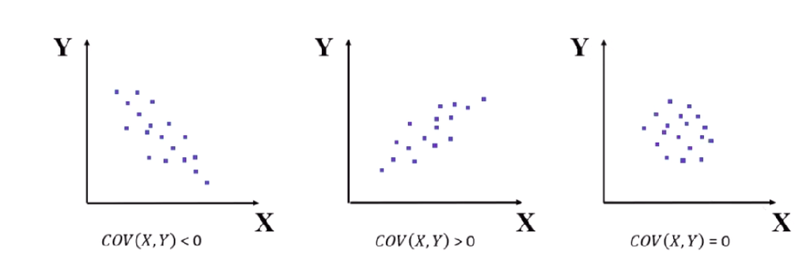

### 2.4.1. Covariance of our dataset

```python
data_set_07.cov()
```

|  | Time | E_Plug | E_Heat | Temp |
| --- | --- | --- | --- | --- |
| Time | 50.000000 | 88.535573 | -0.500000 | 8.217391 |
| E_Plug | 88.535573 | 455.260870 | 25.833992 | 0.154150 |
| E_Heat | -0.500000 | 25.833992 | 47.346014 | -51.206522 |
| Temp | 8.217391 | 0.154150 | -51.206522 | 63.500000 |

```python
co_relation = data_set_07.cov()
co_relation
```

|  | Time | E_Plug | E_Heat | Temp |
| --- | --- | --- | --- | --- |
| Time | 50.000000 | 88.535573 | -0.500000 | 8.217391 |
| E_Plug | 88.535573 | 455.260870 | 25.833992 | 0.154150 |
| E_Heat | -0.500000 | 25.833992 | 47.346014 | -51.206522 |
| Temp | 8.217391 | 0.154150 | -51.206522 | 63.500000 |

```python
import seaborn as sns
```

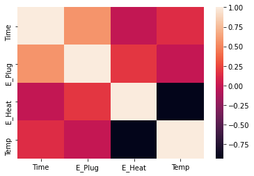

```python
sns.heatmap(data_set_07.corr())
```

## 2.5. Missing Values - Preprocessing

It is not unusual for an object to be missing one or more attribute values. In some cases, the information was not collected; while in other cases, some attributes are inapplicable to the data instances. This section presents examples of the different approaches for handling missing values. Missing Data is a very big problem in real-life scenarios. Missing Data can also refer to as NA(Not Available) values in pandas.

According to the description of the data, the one missing values are encoded as '!' in the original data of the Price column. Our first task is to convert the missing values to NaNs. We can then count the number of missing values in each column of the data.

After converting the missing value to NaN, missing data is represented by two value:

1. None: None is a Python singleton object that is often used for missing data in Python code.
1. NaN: NaN (an acronym for Not a Number), is a special floating-point value recognized by all systems that use the standard IEEE floating-point representation.

```python
data_set_08 = data_set_07.replace('!', np.NaN)

print('Number of instances = %d' % (data_set_08.shape[0]))
print('Number of attributes = %d' % (data_set_08.shape[1]))

print('Number of missing values:')
for col in data_set_08.columns:
    print('\t%s: %d' % (col,data_set_08[col].isna().sum()))
```

```
Number of instances = 24
Number of attributes = 5
Number of missing values:
	Time: 0
	E_Plug: 1
	E_Heat: 0
	Price: 1
	Temp: 0
```

### 2.5.1. Get a concise summary of the dataframe

Now, we have two NaN in our data set. But, the problem is that the exclamation mark "!" made my Price column a categorical variable not the numerical one. So, I should change this to numeric as well then go after further preprocessing of our data set.

```python
data_set_08.info()
```

```
<class 'pandas.core.frame.DataFrame'>
RangeIndex: 24 entries, 0 to 23
Data columns (total 5 columns):
 #   Column  Non-Null Count  Dtype
---  ------  --------------  -----
 0   Time    24 non-null     int64
 1   E_Plug  23 non-null     float64
 2   E_Heat  24 non-null     int64
 3   Price   23 non-null     object
 4   Temp    24 non-null     int64
dtypes: float64(1), int64(3), object(1)
memory usage: 1.1+ KB
```

### 2.5.2. convert categorical variable to numeric

```python
data_set_08['Price'] = data_set_08['Price'].apply(pd.to_numeric)
```

```python
data_set_08.info()
```

```
<class 'pandas.core.frame.DataFrame'>
RangeIndex: 24 entries, 0 to 23
Data columns (total 5 columns):
 #   Column  Non-Null Count  Dtype
---  ------  --------------  -----
 0   Time    24 non-null     int64
 1   E_Plug  23 non-null     float64
 2   E_Heat  24 non-null     int64
 3   Price   23 non-null     float64
 4   Temp    24 non-null     int64
dtypes: float64(2), int64(3)
memory usage: 1.1 KB
```

### 2.5.6. Handling Missing Data Easily

We have three different techniques for handling missing data.

1. Just delete the record which has missing values
2. Create a separate model to handle the missing value
3. Impute missing values with Mean, Median, and Mode values

#### 2.5.6.1. Drop row using index number

```python
data_set_08.drop(13, axis = 0 )
```

|  | Time | E_Plug | E_Heat | Price | Temp |
| --- | --- | --- | --- | --- | --- |
| 0 | 1 | 24.0 | 28 | 10.0 | -15 |
| 1 | 2 | 17.0 | 32 | 12.0 | -17 |
| 2 | 3 | 16.0 | 34 | 11.0 | -19 |
| 3 | 4 | 16.0 | 33 | 12.0 | -18 |
| 4 | 5 | 16.0 | 30 | 10.0 | -14 |
| 5 | 6 | 16.0 | 31 | 10.0 | -16 |
| 6 | 7 | 19.0 | 28 | 14.0 | -14 |
| 7 | 8 | 22.0 | 29 | 12.0 | -15 |
| 8 | 9 | 25.0 | 26 | 12.0 | -12 |
| 9 | 10 | 26.0 | 24 | 14.0 | -8 |
| 10 | 11 | 27.0 | 20 | 14.0 | -4 |
| 11 | 12 | 30.0 | 19 | 16.0 | 0 |
| 12 | 13 | 30.0 | 19 | 16.0 | 0 |
| 14 | 15 | 27.0 | 14 | 17.0 | 3 |
| 15 | 16 | 27.0 | 16 | 17.0 | 2 |
| 16 | 17 | 28.0 | 21 | 18.0 | 0 |
| 17 | 18 | 33.0 | 26 | 20.0 | -6 |
| 18 | 19 | 42.0 | 32 | 21.0 | -8 |
| 19 | 20 | 120.0 | 33 | 21.0 | -12 |
| 20 | 21 | 47.0 | 32 | 21.0 | -16 |
| 21 | 22 | 44.0 | 30 | 22.0 | -18 |
| 22 | 23 | 36.0 | 35 | NaN | -19 |
| 23 | 24 | 37.0 | 36 | 18.0 | -22 |

#### 2.5.6.2. Drop all the NaN cell

```python
data_set_08.dropna(axis = 0)
```

|  | Time | E_Plug | E_Heat | Price | Temp |
| --- | --- | --- | --- | --- | --- |
| 0 | 1 | 24.0 | 28 | 10.0 | -15 |
| 1 | 2 | 17.0 | 32 | 12.0 | -17 |
| 2 | 3 | 16.0 | 34 | 11.0 | -19 |
| 3 | 4 | 16.0 | 33 | 12.0 | -18 |
| 4 | 5 | 16.0 | 30 | 10.0 | -14 |
| 5 | 6 | 16.0 | 31 | 10.0 | -16 |
| 6 | 7 | 19.0 | 28 | 14.0 | -14 |
| 7 | 8 | 22.0 | 29 | 12.0 | -15 |
| 8 | 9 | 25.0 | 26 | 12.0 | -12 |
| 9 | 10 | 26.0 | 24 | 14.0 | -8 |
| 10 | 11 | 27.0 | 20 | 14.0 | -4 |
| 11 | 12 | 30.0 | 19 | 16.0 | 0 |
| 12 | 13 | 30.0 | 19 | 16.0 | 0 |
| 14 | 15 | 27.0 | 14 | 17.0 | 3 |
| 15 | 16 | 27.0 | 16 | 17.0 | 2 |
| 16 | 17 | 28.0 | 21 | 18.0 | 0 |
| 17 | 18 | 33.0 | 26 | 20.0 | -6 |
| 18 | 19 | 42.0 | 32 | 21.0 | -8 |
| 19 | 20 | 120.0 | 33 | 21.0 | -12 |
| 20 | 21 | 47.0 | 32 | 21.0 | -16 |
| 21 | 22 | 44.0 | 30 | 22.0 | -18 |
| 23 | 24 | 37.0 | 36 | 18.0 | -22 |

#### 2.5.6.3. Replace NA or NaN values in the DataFrame with the specified values using fillna() method

Info of Pandas fillna() method:

1. method='ffill': Ffill or forward-fill propagates the last observed non-null value forward until another non-null value is encountered.
1. method='bfill': Bfill or backward-fill propagates the first observed non-null value backward until another non-null value is met.

```python
data_set_08.fillna(method='ffill')
```

|  | Time | E_Plug | E_Heat | Price | Temp |
| --- | --- | --- | --- | --- | --- |
| 0 | 1 | 24.0 | 28 | 10.0 | -15 |
| 1 | 2 | 17.0 | 32 | 12.0 | -17 |
| 2 | 3 | 16.0 | 34 | 11.0 | -19 |
| 3 | 4 | 16.0 | 33 | 12.0 | -18 |
| 4 | 5 | 16.0 | 30 | 10.0 | -14 |
| 5 | 6 | 16.0 | 31 | 10.0 | -16 |
| 6 | 7 | 19.0 | 28 | 14.0 | -14 |
| 7 | 8 | 22.0 | 29 | 12.0 | -15 |
| 8 | 9 | 25.0 | 26 | 12.0 | -12 |
| 9 | 10 | 26.0 | 24 | 14.0 | -8 |
| 10 | 11 | 27.0 | 20 | 14.0 | -4 |
| 11 | 12 | 30.0 | 19 | 16.0 | 0 |
| 12 | 13 | 30.0 | 19 | 16.0 | 0 |
| 13 | 14 | 30.0 | 13 | 17.0 | 2 |
| 14 | 15 | 27.0 | 14 | 17.0 | 3 |
| 15 | 16 | 27.0 | 16 | 17.0 | 2 |
| 16 | 17 | 28.0 | 21 | 18.0 | 0 |
| 17 | 18 | 33.0 | 26 | 20.0 | -6 |
| 18 | 19 | 42.0 | 32 | 21.0 | -8 |
| 19 | 20 | 120.0 | 33 | 21.0 | -12 |
| 20 | 21 | 47.0 | 32 | 21.0 | -16 |
| 21 | 22 | 44.0 | 30 | 22.0 | -18 |
| 22 | 23 | 36.0 | 35 | 22.0 | -19 |
| 23 | 24 | 37.0 | 36 | 18.0 | -22 |

```python
data_set_08.fillna(method = 'bfill')
```

|  | Time | E_Plug | E_Heat | Price | Temp |
| --- | --- | --- | --- | --- | --- |
| 0 | 1 | 24.0 | 28 | 10.0 | -15 |
| 1 | 2 | 17.0 | 32 | 12.0 | -17 |
| 2 | 3 | 16.0 | 34 | 11.0 | -19 |
| 3 | 4 | 16.0 | 33 | 12.0 | -18 |
| 4 | 5 | 16.0 | 30 | 10.0 | -14 |
| 5 | 6 | 16.0 | 31 | 10.0 | -16 |
| 6 | 7 | 19.0 | 28 | 14.0 | -14 |
| 7 | 8 | 22.0 | 29 | 12.0 | -15 |
| 8 | 9 | 25.0 | 26 | 12.0 | -12 |
| 9 | 10 | 26.0 | 24 | 14.0 | -8 |
| 10 | 11 | 27.0 | 20 | 14.0 | -4 |
| 11 | 12 | 30.0 | 19 | 16.0 | 0 |
| 12 | 13 | 30.0 | 19 | 16.0 | 0 |
| 13 | 14 | 27.0 | 13 | 17.0 | 2 |
| 14 | 15 | 27.0 | 14 | 17.0 | 3 |
| 15 | 16 | 27.0 | 16 | 17.0 | 2 |
| 16 | 17 | 28.0 | 21 | 18.0 | 0 |
| 17 | 18 | 33.0 | 26 | 20.0 | -6 |
| 18 | 19 | 42.0 | 32 | 21.0 | -8 |
| 19 | 20 | 120.0 | 33 | 21.0 | -12 |
| 20 | 21 | 47.0 | 32 | 21.0 | -16 |
| 21 | 22 | 44.0 | 30 | 22.0 | -18 |
| 22 | 23 | 36.0 | 35 | 18.0 | -19 |
| 23 | 24 | 37.0 | 36 | 18.0 | -22 |

#### 2.5.6.4. Impute missing values with Mean, Median, and Mode values

A question may arise in our mind, which is better replacement by mean, replacement by median, or replacement by mode?

Answer: It always depends on our data and on our tasks. Often a simple, if not always satisfactory, the choice for missing values that are known not to be zero is to use some ``central'' value of the variable. This is often the mean, median, or mode, and thus usually has limited impact on the distribution. We might choose to use the mean, for example, if the variable is otherwise generally normally distributed (and in particular does not have any skewness). If the data does exhibit some skewness though (e.g., there are a small number of very large values) then the median might be a better choice.

For categoric variables, there is, of course, no mean nor median, and so in such cases, we might choose to use the mode (the most frequent value) as the default to fill in for the otherwise missing values. The mode can also be used for numeric variables.

When reviewing an observation from the below box plot, the value 120 of the 'E_plug' column is defined as an outlier that is located outside the whiskers of the box plot. So, the NaN value is filled with the median of that column.

Similarly, there is no value locate outside the whiskers of the box plot in the 'Price' column. So, the NaN value is filled with the mean of that column.

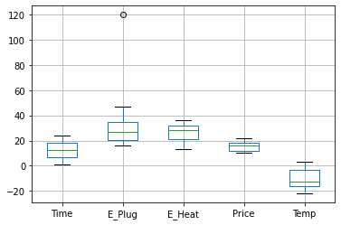

```python
data_set_08.boxplot()
```

##### 2.5.6.4.1. impute missing value of 'E_plug' using median

```python
data_set_08['E_Plug'].fillna((data_set_08['E_Plug'].median()), inplace=True)
```

##### 2.5.6.4.2. impute missing value of 'Price' using mean

```python
data_set_08['Price'].fillna((data_set_08['Price'].mean()), inplace=True)
```

```python
data_set_08.iloc[13:24]
```

|  | Time | E_Plug | E_Heat | Price | Temp |
| --- | --- | --- | --- | --- | --- |
| 13 | 14 | 27.0 | 13 | 17.000000 | 2 |
| 14 | 15 | 27.0 | 14 | 17.000000 | 3 |
| 15 | 16 | 27.0 | 16 | 17.000000 | 2 |
| 16 | 17 | 28.0 | 21 | 18.000000 | 0 |
| 17 | 18 | 33.0 | 26 | 20.000000 | -6 |
| 18 | 19 | 42.0 | 32 | 21.000000 | -8 |
| 19 | 20 | 120.0 | 33 | 21.000000 | -12 |
| 20 | 21 | 47.0 | 32 | 21.000000 | -16 |
| 21 | 22 | 44.0 | 30 | 22.000000 | -18 |
| 22 | 23 | 36.0 | 35 | 15.434783 | -19 |
| 23 | 24 | 37.0 | 36 | 18.000000 | -22 |

## 2.6. Outlier Concept - Preprocessing

Outliers are data instances with characteristics that are considerably different from the rest of the dataset. In the example code below, we will draw a boxplot to identify the columns in the table that contain outliers.

Note that the values in all columns (except for 'E_plug' and 'Price') are originally stored as 'int64' whereas the values in the 'Price' column are stored as string objects and(since the column initially contains strings such as '!' for representing missing values). Thus, we must convert the column into numeric values first before creating the boxplot. Otherwise, the column will not be displayed when drawing the boxplot.

Additionally, we have the 'E_plug' column where one of the cell is initially present with NaN value.

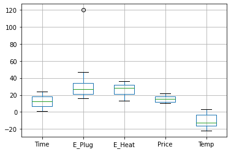

```python
data_set_08.boxplot()
```

### 2.6.1. How to calculate outlier Interquartile Range Rule

The interquartile range rule is useful in detecting the presence of outliers. Outliers are individual values that fall outside of the overall pattern of a data set. This definition is somewhat vague and subjective, so it is helpful to have the rule to apply when determining whether a data point is truly an outlier—this is where the interquartile range rule comes in.

#### 2.6.1.1. What Is the Interquartile Range?

Any set of data can be described by its five-number summary. These five numbers, which give you the information you need to find patterns and outliers, consist of (in ascending order):

1. The median of the data set, which represents the midpoint of the whole list of data
2. The first quartile Q1, which represents a quarter of the way through the list of all data
3. The third quartile Q3, which represents three-quarters of the way through the list of all data
4. The minimum or lowest value of the dataset
5. The maximum or highest value of the data set.

Let's take an example:

Data = [4, 2, 5, 3, 7, 5, 6, 9, 32, 2]

Arranging Data in Ascending order: [2, 2, 3, 4, 5, 5, 6, 7, 9, 32]

Median = $\frac{5+5}{2} = 5$

After Calculating median, our new data = [2, 2, 3, 4, 5, 5, 5, 6, 7, 9, 32]

The first quartile Q1 = $\frac{ 3 + 4}{2} = 3.5$

The third quartile Q3 = $\frac{6 + 7}{2} = 6.5$

Minimum or lowest value of the data = 2

The interquartile range is calculated in much the same way as the range. All we do to find it is subtract the first quartile from the third quartile:

interquartile Range Formula = ${Q_3} - {Q_1} = 6.5 - 3.5 = 3$

There are two standard to find outlier:

1. Mild Outlier: A point beyond an inner fence on either side is considered a mild outlier.

1. Extreme Outlier: A point beyond an outer fence is considered an extreme outlier.

Q1 - 3 *IQR(Lower) = 3.5 - 3* 3 = -5.5  
Q3 + 3 + IQR(Upper) = 6.5 + 3 * 3 = 15.5

Note: The outlier is identified as the largest value in the data set, 32, and appears as the circle to the right of the box plot.

#### From Above information we get following box plot

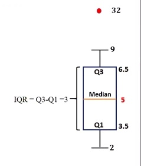

### 2.6.2. How can we calculate value 120 of 'E_plug' column as outlier?

```python
q1 = data_set_08['E_Plug'].quantile(0.25)
q3 = data_set_08['E_Plug'].quantile(0.75)
print('Q1 and Q3 of E_plug column is {} and {}'.format(q1, q3))

IQR = q3 - q1
print('\nInterquartile Range is', IQR)
```

```
Q1 and Q3 of E_plug column is 21.25 and 33.75

Interquartile Range is 12.5
```

We need to calculate Mild Outlier and Extreme Outlier For Mild Outlier 1. Lower Bound = Q1 - 1.5 * IQR(Lower) = 21.25 - 1.5 * 12.5 = 2.5 2. Upper Bound = Q3 - 1.5 * IQR(upper) = 33.75 + 1.5 * 12.5 = 52.5 For Extreme Outlier 1. Lower Bound = Q1 - 3 * IQR(Lower) = 21.25 - 3 * 12.5 = -16.25 2. Upper Bound = Q3 - 3 * IQR(upper) = 33.75 + 3 * 12.5 = 71.25 so, the outlier is identified as the largest value in the data set, 120, and appears as the circle to the right of the box plot.

### 2.6.3. Replace outlier value with mean value

```python
data_set_08['E_Plug'].replace(120, (data_set_08['E_Plug'].mean()), inplace=True)
data_set_08[18:24]
```

|  | Time | E_Plug | E_Heat | Price | Temp |
| --- | --- | --- | --- | --- | --- |
| 18 | 19 | 42.000000 | 32 | 21.000000 | -8 |
| 19 | 20 | 31.333333 | 33 | 21.000000 | -12 |
| 20 | 21 | 47.000000 | 32 | 21.000000 | -16 |
| 21 | 22 | 44.000000 | 30 | 22.000000 | -18 |
| 22 | 23 | 36.000000 | 35 | 15.434783 | -19 |
| 23 | 24 | 37.000000 | 36 | 18.000000 | -22 |

## 2.7. Concatenating - Preprocessing

In computer programming and data processing, two or more character strings/ Rows/ Columns are sometimes concatenated for the purpose of saving space or so that they can be addressed as a single item.

### 2.7.1. Import new data set and concat new data set with our preprocessed data

```python
new_col = pd.read_csv('Data_New.csv')
```

Note: This is my trick with axis: just add the operation in your mind to make it sound clear: 1. axis 0 = rows 2. axis 1 = columns If we “sum” through axis=0, we are summing all rows, and the output will be a single row with the same number of columns. If we “sum” through axis=1, we are summing all columns, and the output will be a single column with the same number of rows.

If someone needs visual description, here is the image: (Image taken from Google)

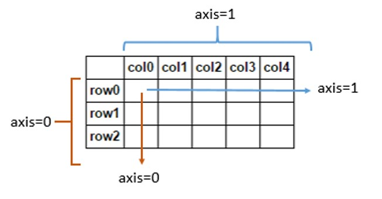

```python
data_set_09 = pd.concat([data_set_08, new_col], axis = 1)
data_set_09.head()
```

|  | Time | E_Plug | E_Heat | Price | Temp | P/OffP |
| --- | --- | --- | --- | --- | --- | --- |
| 0 | 1 | 24.0 | 28 | 10.0 | -15 | OffPeak |
| 1 | 2 | 17.0 | 32 | 12.0 | -17 | OffPeak |
| 2 | 3 | 16.0 | 34 | 11.0 | -19 | OffPeak |
| 3 | 4 | 16.0 | 33 | 12.0 | -18 | OffPeak |
| 4 | 5 | 16.0 | 30 | 10.0 | -14 | OffPeak |

## 2.8. Dummy Coding - Preprocessing

Dummy variables (also known as one-hot encoding) consists on transforming a categorical feature into a form that is better understood by several algorithms. Let’s say we have a feature called color which has one of three options (red, green and blue). Most algorithms can’t interpret the text so we would need to convert each value into a number. We could potentially replace red with 1, green with 2 and blue with 3. This could work, but it has an underlying assumption that red is closer to green than to blue. It can also be interpreted as blue being more important than red since it has a higher value. This may not necessarily be the case. A solution that addresses these challenges is to apply dummy variables. We can replace the color feature with three new features called red, green and blue. This would be the breakdown for each color:

[output not shown]

In this case, we no longer indicate that one color is more important than any other, or that two colors are more similar than others. Note that we could also get rid of one of the columns (i.e. the Blue column), and assume that if both Red and Green have 0’s, then this automatically indicates that Blue is equal to 1.

In our last observation the variable that should take values as 0 and 1, where the values indicate the presence or absence peak.

Example: A 0 may indicate a Peak and 1 may indicate an offpeak). Where a categorical variable has more than two categories, it can be represented by a set of dummy variables, with one variable for each category.

Note: Numeric variables can also be dummy coded to explore nonlinear effects. Dummy variables are also known as indicator variables, design variables, contrasts, one-hot coding, and binary basis variables

### 2.8.1. Get a concise summary of the new dataframe

Actually, we have removed all the null cells so we don't have missing values or something. But in the type section except for P/OffP, we have all the columns are in integer or float. TO convert this categorical column to the numeric column to make the machine understandable for our machine. We need to use the get_dummies() feature of pandas’ library.

```python
data_set_09.info()
```

```
<class 'pandas.core.frame.DataFrame'>
RangeIndex: 24 entries, 0 to 23
Data columns (total 6 columns):
 #   Column   Non-Null Count  Dtype
---  ------   --------------  -----
 0   Time     24 non-null     int64
 1   E_Plug   24 non-null     float64
 2   E_Heat   24 non-null     int64
 3   Price    24 non-null     float64
 4   Temp     24 non-null     int64
 5   P/OffP   24 non-null     object
dtypes: float64(2), int64(3), object(1)
memory usage: 1.2+ KB
```

### 2.8.2 Categorical column to the numeric column

```python
data_set_10 = pd.get_dummies(data_set_09)
data_set_10.head()
```

|  | Time | E_Plug | E_Heat | Price | Temp | P/OffP _OffPeak | P/OffP _Peak |
| --- | --- | --- | --- | --- | --- | --- | --- |
| 0 | 1 | 24.0 | 28 | 10.0 | -15 | 1 | 0 |
| 1 | 2 | 17.0 | 32 | 12.0 | -17 | 1 | 0 |
| 2 | 3 | 16.0 | 34 | 11.0 | -19 | 1 | 0 |
| 3 | 4 | 16.0 | 33 | 12.0 | -18 | 1 | 0 |
| 4 | 5 | 16.0 | 30 | 10.0 | -14 | 1 | 0 |

## 2.9. Normalization - Preprocessing

When we construct a building, house, or road, there is a leveling done before the construction starts. Everything is brought to a level and then the building is erected.

Likewise, normalization is done so that all the data is at the same level and then we can run whatever algorithm is used. Building these data-related solutions requires the data to be brought to a level before any algorithm is applied.

In python, we have several packages for Normalization.

1. Min Max Scaler Sub-Package: $\frac{x-x_{min}}{x_{max} - x_{min}}$
2. Normalize Sub Package:  
   a. L1 Norm (Manhattan Distance): $ \frac{x_{ij}}{|x_1| + |x_2| + |x_3| + .... +|x_n|} $

   b. L2 Norm (Euclidean Distance): $ \frac{x_{ij}}{\sqrt{{x_1}^2 + {x_2}^2 + {x_3}^3 + .... +{x_n}^2}} $

### 2.9.1. Normalize our preprocessed data

```python
from sklearn.preprocessing import minmax_scale, normalize
```

```python
# First Method: Min Max Scale

data_set_11 = minmax_scale(data_set_10.iloc[:,0:5], feature_range=(0,1))

# Second Method: using L2 Normalization

data_set_12 = normalize(data_set_10.iloc[:,0:5], norm='l2', axis = 0)

# axis = 0 for normalizing features where axis = 1 is for normalizing each sample
```

### 2.9.2. Convert normalize data into pandas dataframe with proper header

```python
data_set_13 = pd.DataFrame(data_set_12, columns = ['Time', 'E_Plug', 'E_Heat', 'Price', 'Temp'])
data_set_13.head()
```

|  | Time | E_Plug | E_Heat | Price | Temp |
| --- | --- | --- | --- | --- | --- |
| 0 | 0.014286 | 0.168948 | 0.207499 | 0.128488 | -0.237706 |
| 1 | 0.028571 | 0.119671 | 0.237141 | 0.154186 | -0.269400 |
| 2 | 0.042857 | 0.112632 | 0.251962 | 0.141337 | -0.301095 |
| 3 | 0.057143 | 0.112632 | 0.244552 | 0.154186 | -0.285248 |
| 4 | 0.071429 | 0.112632 | 0.222320 | 0.128488 | -0.221859 |

### 2.9.3. Concat normalize data with target variable

```python
data_set_14 = pd.concat([data_set_13, data_set_10['P/OffP _OffPeak'], data_set_10['P/OffP _Peak']], axis = 1)
```

```python
data_set_14.head()
```

|  | Time | E_Plug | E_Heat | Price | Temp | P/OffP _OffPeak | P/OffP _Peak |
| --- | --- | --- | --- | --- | --- | --- | --- |
| 0 | 0.014286 | 0.168948 | 0.207499 | 0.128488 | -0.237706 | 1 | 0 |
| 1 | 0.028571 | 0.119671 | 0.237141 | 0.154186 | -0.269400 | 1 | 0 |
| 2 | 0.042857 | 0.112632 | 0.251962 | 0.141337 | -0.301095 | 1 | 0 |
| 3 | 0.057143 | 0.112632 | 0.244552 | 0.154186 | -0.285248 | 1 | 0 |
| 4 | 0.071429 | 0.112632 | 0.222320 | 0.128488 | -0.221859 | 1 | 0 |

### 2.10 Summary

This tutorial presents Python programming examples for data preprocessing, including data cleaning to handle missing values and remove outliers as well as duplicate data.

# 😊 Thanks for your time 😊

What do you think of this “Data Preprocessing“? (Appreciation, Suggestions, and Questions are highly appreciated).